# Artificial Neural Network

## Using ANN for Classifying News Articles

Using a feedforward artificial neural network to classify Reuters news into 46 different topics/classes.

```r
library(keras)

reuters <- dataset_reuters(num_words = 10000)

one_hot_encoding <- function(x, dimension = 10000) {
  encoded <- matrix(0, length(x), dimension)
  for (i in 1:length(x))
    encoded[i, x[[i]]] = 1
  encoded
}

train_x <- one_hot_encoding(reuters$train$x)
test_x <- one_hot_encoding(reuters$test$x)

train_y <- to_categorical(reuters$train$y)
test_y <- to_categorical(reuters$test$y)
```

**Creating an ANN model to classify the Reuters news article into 46 classes using at least two hidden layers and computing the accuracy of the model on the test set.**

```r
model <- keras_model_sequential()
model %>%
  layer_dense(units = 64, activation = "relu", input_shape = c(10000)) %>%
  layer_dense(units = 64, activation = "relu") %>%
  layer_dense(units = 46, activation = "softmax")

model %>% compile(
  optimizer = 'adam',
  loss = 'categorical_crossentropy',
  metric = c('accuracy'))

model %>% evaluate(test_x, test_y)
```

```
##        loss    accuracy
## 3.844928741 0.005342832
```

**Split the train data into train/validation set. Use the first 1000 examples in reuters$train for validation and the rest for training the model. Use “tfruns” to tune the ANN’s hyper-paramaters - Validate each model on the validation set.**

```r
library(tfruns)

split_index <- 1:1000

validation_split_x <- train_x[split_index,]
training_split_x <- train_x[-split_index,]

validation_split_y <- train_y[split_index,]
training_split_y <- train_y[-split_index,]

set.seed(111)

model %>% fit(
    training_split_x,
    training_split_y,
    epochs = 20,
    batch_size = 100,
    validation_data = list(validation_split_x, validation_split_y)
)

model %>% evaluate(test_x, test_y)
```

```
##      loss  accuracy
## 1.1667222 0.7858415
```

```
runs <- tuning_run("reuters.R",
                   flags = list(
                     nodes = c(64, 128, 392),
                     learning_rate = c(0.01, 0.05, 0.001, 0.0001),
                     batch_size = c(100, 200, 500, 1000),
                     epochs = c(30, 50, 100),
                     activation = c("relu", "sigmoid", "tanh")),
                     sample = 0.2
                   )

runs
view_run(runs$run_dir[1])
```

The run with the highest validation accuracy had 64 neurons, with sigmoid activation function, was trained with 100 epochs and a learning rate of 0.001 and batch size of 200.

- loss: 0.0581
- accuracy: 0.9609
- validation loss: 1.0969
- validation accuracy: 0.7990

The best model still overfits. The accuracy of the training set is better than the accuracy of the validation set. The validation error is higher than the training error. The validation loss stops decreasing rapidly at about epoch 10, leveling off around epoch 30, and begins rising slightly around epoch 37.

**Use all of the training data in reuters$train to train an ANN with the best hyper-parameter combination and compute the accuracy of the model on the test set.**

```r
tuned_model <- keras_model_sequential() %>%
  layer_dense(units = 64, activation = "sigmoid", input_shape = c(10000)) %>%
  layer_dense(units = 64, activation = "sigmoid") %>%
  layer_dense(units = 46, activation = "softmax")

tuned_model %>% compile(
  optimizer = 'adam',
  loss = 'categorical_crossentropy',
  metric = c('accuracy'))

tuned_model %>% fit(
    train_x,
    train_y,
    epochs = 100,
    batch_size = 200,
    validation_data = list(validation_split_x, validation_split_y)
)

tuned_model %>% evaluate(test_x, test_y)
```

```
##      loss  accuracy
## 1.2267933 0.7907391
```

## Predicting Baseball Player’s Salaries

```r
baseball <- read.csv("hitters.csv", header = TRUE)
str(baseball)
```

```
## 'data.frame':    322 obs. of  20 variables:
##  $ AtBat    : int  293 315 479 496 321 594 185 298 323 401 ...
##  $ Hits     : int  66 81 130 141 87 169 37 73 81 92 ...
##  $ HmRun    : int  1 7 18 20 10 4 1 0 6 17 ...
##  $ Runs     : int  30 24 66 65 39 74 23 24 26 49 ...
##  $ RBI      : int  29 38 72 78 42 51 8 24 32 66 ...
##  $ Walks    : int  14 39 76 37 30 35 21 7 8 65 ...
##  $ Years    : int  1 14 3 11 2 11 2 3 2 13 ...
##  $ CAtBat   : int  293 3449 1624 5628 396 4408 214 509 341 5206 ...
##  $ CHits    : int  66 835 457 1575 101 1133 42 108 86 1332 ...
##  $ CHmRun   : int  1 69 63 225 12 19 1 0 6 253 ...
##  $ CRuns    : int  30 321 224 828 48 501 30 41 32 784 ...
##  $ CRBI     : int  29 414 266 838 46 336 9 37 34 890 ...
##  $ CWalks   : int  14 375 263 354 33 194 24 12 8 866 ...
##  $ League   : chr  "A" "N" "A" "N" ...
##  $ Division : chr  "E" "W" "W" "E" ...
##  $ PutOuts  : int  446 632 880 200 805 282 76 121 143 0 ...
##  $ Assists  : int  33 43 82 11 40 421 127 283 290 0 ...
##  $ Errors   : int  20 10 14 3 4 25 7 9 19 0 ...
##  $ Salary   : num  NA 475 480 500 91.5 750 70 100 75 1100 ...
##  $ NewLeague: chr  "A" "N" "A" "N" ...
```

```r
summary(baseball)
```

```
##      AtBat            Hits         HmRun            Runs
##  Min.   : 16.0   Min.   :  1   Min.   : 0.00   Min.   :  0.00
##  1st Qu.:255.2   1st Qu.: 64   1st Qu.: 4.00   1st Qu.: 30.25
##  Median :379.5   Median : 96   Median : 8.00   Median : 48.00
##  Mean   :380.9   Mean   :101   Mean   :10.77   Mean   : 50.91
##  3rd Qu.:512.0   3rd Qu.:137   3rd Qu.:16.00   3rd Qu.: 69.00
##  Max.   :687.0   Max.   :238   Max.   :40.00   Max.   :130.00
##
##       RBI             Walks            Years            CAtBat
##  Min.   :  0.00   Min.   :  0.00   Min.   : 1.000   Min.   :   19.0
##  1st Qu.: 28.00   1st Qu.: 22.00   1st Qu.: 4.000   1st Qu.:  816.8
##  Median : 44.00   Median : 35.00   Median : 6.000   Median : 1928.0
##  Mean   : 48.03   Mean   : 38.74   Mean   : 7.444   Mean   : 2648.7
##  3rd Qu.: 64.75   3rd Qu.: 53.00   3rd Qu.:11.000   3rd Qu.: 3924.2
##  Max.   :121.00   Max.   :105.00   Max.   :24.000   Max.   :14053.0
##
##      CHits            CHmRun           CRuns             CRBI
##  Min.   :   4.0   Min.   :  0.00   Min.   :   1.0   Min.   :   0.00
##  1st Qu.: 209.0   1st Qu.: 14.00   1st Qu.: 100.2   1st Qu.:  88.75
##  Median : 508.0   Median : 37.50   Median : 247.0   Median : 220.50
##  Mean   : 717.6   Mean   : 69.49   Mean   : 358.8   Mean   : 330.12
##  3rd Qu.:1059.2   3rd Qu.: 90.00   3rd Qu.: 526.2   3rd Qu.: 426.25
##  Max.   :4256.0   Max.   :548.00   Max.   :2165.0   Max.   :1659.00
##
##      CWalks           League            Division            PutOuts
##  Min.   :   0.00   Length:322         Length:322         Min.   :   0.0
##  1st Qu.:  67.25   Class :character   Class :character   1st Qu.: 109.2
##  Median : 170.50   Mode  :character   Mode  :character   Median : 212.0
##  Mean   : 260.24                                         Mean   : 288.9
##  3rd Qu.: 339.25                                         3rd Qu.: 325.0
##  Max.   :1566.00                                         Max.   :1378.0
##
##     Assists          Errors          Salary        NewLeague
##  Min.   :  0.0   Min.   : 0.00   Min.   :  67.5   Length:322
##  1st Qu.:  7.0   1st Qu.: 3.00   1st Qu.: 190.0   Class :character
##  Median : 39.5   Median : 6.00   Median : 425.0   Mode  :character
##  Mean   :106.9   Mean   : 8.04   Mean   : 535.9
##  3rd Qu.:166.0   3rd Qu.:11.00   3rd Qu.: 750.0
##  Max.   :492.0   Max.   :32.00   Max.   :2460.0
##                                  NA's   :59
```

There are 322 observations. Out of 20 variables, 3 are categorical and the remaining 17 are numeric. There are 59 missing values - all within the ‘Salary’ variable.

The histogram for ‘Salary’ is right-skewed and tending toward a unimodal distribution. There are outliers that are greater than the mode of the data.

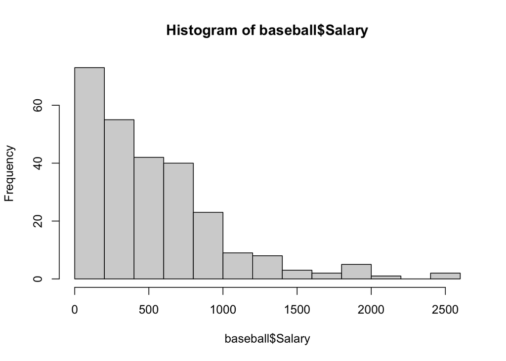

```r
hist(baseball$Salary)
```

**Remove the obs in which ‘Salary’ is missing.**

```r
baseball <- na.omit(baseball)
sum(is.na(baseball))
```

```
## [1] 0
```

**Which predictors have the most correlation with ‘Salary’?**

Numeric:  
* AtBat: There does not appear to be correlation.  
* Hits: There does not appear to be correlation, or it is very weak.  
* HmRun: There does not appear to be correlation.  
* Runs: There does not appear to be correlation, or it is very weak.  
* RBI: There does not appear to be correlation, or it is very weak.  
* Walks: There does not appear to be correlation, or it is very weak.  
* Years: There appears to be slight correlation.  
* CAtBat: There appears to be slight correlation.  
* CHits: There appears to be slight correlation.  
* CHmRun: There appears to be slight correlation.  
* CRuns: There appears to be slight correlation.  
* CRBI: There appears to be slight correlation.  
* CWalks: There appears to be slight correlation.  
* PutOuts: There does not appear to be correlation.  
* Assists: There does not appear to be correlation.  
* Errors: There does not appear to be correlation.

Categorical:  
* League: The p-value is 0.8171, therefore I do not see a correlation.  
* Division: The p-value is 0.001892, therefore I do see a correlation.  
* NewLeague: The p-value is 0.9634, therefore I do not see a correlation.

```
numeric_attributes <- baseball[, c("AtBat", "Hits", "HmRun", "Runs", "RBI", "Walks", "Years", "CAtBat", "CHits", "CHmRun", "CRuns", "CRBI", "CWalks", "PutOuts", "Assists", "Errors", "Salary")]
cor(numeric_attributes)

plot(baseball$Salary, baseball$AtBat)
plot(baseball$Salary, baseball$Hits)
plot(baseball$Salary, baseball$HmRun)
plot(baseball$Salary, baseball$Runs)
plot(baseball$Salary, baseball$RBI)
plot(baseball$Salary, baseball$Walks)
plot(baseball$Salary, baseball$Years)
plot(baseball$Salary, baseball$CAtBat)
plot(baseball$Salary, baseball$CHits)
plot(baseball$Salary, baseball$CHmRun)
plot(baseball$Salary, baseball$CRuns)
plot(baseball$Salary, baseball$CRBI)
plot(baseball$Salary, baseball$CWalks)
plot(baseball$Salary, baseball$PutOuts)
plot(baseball$Salary, baseball$Assists)
plot(baseball$Salary, baseball$Errors)

boxplot(baseball$Salary ~ baseball$League)
t.test(baseball$Salary ~ baseball$League)
boxplot(baseball$Salary ~ baseball$Division)
t.test(baseball$Salary ~ baseball$Division)
boxplot(baseball$Salary ~ baseball$NewLeague)
t.test(baseball$Salary ~ baseball$NewLeague)
```

```r
set.seed(1)
```

**Use Caret’s “createDataPartition” method to partition the dataset into hitters_train (90%) & hitters_test (10%):**

```r
library(caret)
inTrain <- createDataPartition(baseball$Salary, p=0.9, list=FALSE)
baseball_train <- baseball[inTrain, ]
baseball_test <- baseball[-inTrain, ]
```

**Neural networks do not accept categorical variables. Use ifelse to convert the binary categorical variables to a numeric variable of 0/1:**

```r
baseball_train$League <- ifelse(baseball_train$League == "N", 1, 0)
baseball_train$Division <- ifelse(baseball_train$Division == "W", 1, 0)
baseball_train$NewLeague <- ifelse(baseball_train$NewLeague == "N", 1, 0)

baseball_test$League <- ifelse(baseball_test$League == "N", 1, 0)
baseball_test$Division <- ifelse(baseball_test$Division == "W", 1, 0)
baseball_test$NewLeague <- ifelse(baseball_test$NewLeague == "N", 1, 0)

baseball_train$Salary <- log(baseball_train$Salary)
```

**Set seed and further divide the train data into 90% training and 10% validation:**

```r
set.seed(1)

sTrain <- createDataPartition(baseball_train$Salary, p=0.9, list=FALSE)
split_train <- baseball_train[sTrain, ]
split_val <- baseball_train[-sTrain, ]
```

**Scale the numeric attributes in the training data (except for ‘Salary’ & dummy variables):**

```r
library(tidyverse)
x_train <- split_train %>%
    select(-Salary, -League, -Division, -NewLeague) %>%
    scale()
col_mean_train <- attr(x_train, "scaled:center")
col_stddevs_train <- attr(x_train, "scaled:scale")

train_col <- split_train[,c(14,15,20)]
x_train <- cbind(as.data.frame(x_train), train_col)

y_train <- split_train$Salary

x_val <- split_val %>%
    select(-Salary, -League, -Division, -NewLeague) %>%
    scale()
val_col <- split_val[,c(14,15,20)]
x_val <- cbind(as.data.frame(x_val), val_col)

y_val <- split_val$Salary
```

**Create an ANN model to predict log(Salary) from the other attributes:**

The best hyper-parameter combination was the 2nd run: 10 nodes, 100 epochs, and 50 batch size. It very slightly overfits, because the training set runs better than the validation set. It continues to decrease slightly, but mostly levels off at the 17th epoch.

- loss: 0.1344
- mean absolute error: 0.2801
- validation loss: 0.2301
- validation mean absolute error: 0.3884

```r
bb_model <- keras_model_sequential() %>%
    layer_dense(units = 10, activation = "relu", input_shape = ncol(x_train)) %>%
    layer_dense(units = 10) %>%
    layer_dense(units = 1)

bb_model %>% compile(
    optimizer = 'sgd',
    loss = 'mse',
    metric = list('mean_absolute_error'))

set.seed(1)

bb_model %>% fit(
    as.matrix(x_train),
    y_train,
    epochs = 100,
    batch_size = 50,
    validation_data = list(as.matrix(x_val), y_val)
)
```

```
bb_runs <- tuning_run("baseball.R",
                   flags = list(
                       nodes = c(5, 10, 20),
                       learning_rate = c(0.01, 0.05, 0.001, 0.0001),
                       batch_size = c(30, 50, 100, 200),
                       epochs = c(20, 30, 50, 100),
                       activation = c("relu")),
                   sample = 0.2
)

bb_runs
View(bb_runs)
```

**10. Measure the performance of your best model (after tuning) on the test set and compute RMSE.**

```r
set.seed(1)

x_test <- baseball_test %>%
    select(-Salary, -League, -Division, -NewLeague) %>%
    scale(center = col_mean_train, scale = col_stddevs_train)

test_col <- baseball_test[,c(14,15,20)]
x_test <- cbind(as.data.frame(x_test), test_col)
test_matrix <- as.matrix(x_test)

set.seed(1)
predictions <- bb_model %>% predict(test_matrix)
rmse <- function(x, y) { return((mean((x-y)^2))^0.5) }
rmse(exp(predictions), baseball_test$Salary)
```

```
## [1] 429.9277
```

**11. Use a linear regression model to predict the salary using the same data used for the ANN and compare the RMSE of each:**

The ANN does a better job of predicting salary than the linear regression models (linear & stepwise). The ANN has an error that is significantly less than the regression models ($744 error).

```r
library(leaps)

set.seed(1)

train.control <- trainControl(method = "cv", number = 10)
lr_model <- train(Salary~., data = baseball_train, method = "lm", trControl = train.control)
print(lr_model)
```

```
## Linear Regression
##
## 239 samples
##  19 predictor
##
## No pre-processing
## Resampling: Cross-Validated (10 fold)
## Summary of sample sizes: 215, 214, 215, 214, 216, 215, ...
## Resampling results:
##
##   RMSE       Rsquared   MAE
##   0.6568773  0.4688793  0.5374434
##
## Tuning parameter 'intercept' was held constant at a value of TRUE
```

```r
summary(lr_model)
```

```
##
## Call:
## lm(formula = .outcome ~ ., data = dat)
##
## Residuals:
##      Min       1Q   Median       3Q      Max
## -2.23082 -0.43862  0.08339  0.37684  2.73027
##
## Coefficients:
##               Estimate Std. Error t value Pr(>|t|)
## (Intercept)  4.659e+00  1.865e-01  24.984  < 2e-16 ***
## AtBat       -3.173e-03  1.299e-03  -2.443  0.01537 *
## Hits         1.496e-02  4.943e-03   3.027  0.00277 **
## HmRun        1.597e-02  1.311e-02   1.218  0.22469
## Runs        -4.028e-03  6.169e-03  -0.653  0.51450
## RBI         -3.650e-03  5.389e-03  -0.677  0.49887
## Walks        1.195e-02  3.859e-03   3.096  0.00222 **
## Years        6.376e-02  2.689e-02   2.371  0.01859 *
## CAtBat       6.118e-05  2.980e-04   0.205  0.83750
## CHits       -4.007e-04  1.437e-03  -0.279  0.78062
## CHmRun      -3.072e-05  3.303e-03  -0.009  0.99259
## CRuns        1.952e-03  1.530e-03   1.276  0.20329
## CRBI         1.983e-04  1.400e-03   0.142  0.88750
## CWalks      -1.780e-03  6.974e-04  -2.552  0.01140 *
## League       2.793e-01  1.557e-01   1.794  0.07426 .
## Division    -1.901e-01  8.271e-02  -2.299  0.02247 *
## PutOuts      3.402e-04  1.643e-04   2.071  0.03956 *
## Assists      5.505e-04  4.537e-04   1.213  0.22627
## Errors      -1.043e-02  8.873e-03  -1.175  0.24127
## NewLeague   -1.753e-01  1.553e-01  -1.129  0.26015
## ---
## Signif. codes:  0 '***' 0.001 '**' 0.01 '*' 0.05 '.' 0.1 ' ' 1
##
## Residual standard error: 0.6167 on 219 degrees of freedom
## Multiple R-squared:  0.5525, Adjusted R-squared:  0.5137
## F-statistic: 14.23 on 19 and 219 DF,  p-value: < 2.2e-16
```

```r
predict_lr_test <- predict(lr_model, newdata = baseball_test)
rmse(baseball_test$Salary, predict_lr_test)
```

```
## [1] 744.1207
```

```r
set.seed(1)
step.model <- train(Salary~., data = baseball_train, method = "leapBackward", trControl = train.control, tuneGrid = data.frame(nvmax = 1:20))
print(step.model)
```

```
## Linear Regression with Backwards Selection
##
## 239 samples
##  19 predictor
##
## No pre-processing
## Resampling: Cross-Validated (10 fold)
## Summary of sample sizes: 215, 214, 215, 214, 216, 215, ...
## Resampling results across tuning parameters:
##
##   nvmax  RMSE       Rsquared   MAE
##    1     0.7270726  0.3520513  0.5956756
##    2     0.6740321  0.4511602  0.5434375
##    3     0.6805804  0.4440943  0.5476442
##    4     0.6897660  0.4296460  0.5559987
##    5     0.6892469  0.4282438  0.5557075
##    6     0.6743701  0.4524285  0.5436930
##    7     0.6563678  0.4714061  0.5290300
##    8     0.6403024  0.4944594  0.5179887
##    9     0.6407965  0.4935035  0.5200853
##   10     0.6421441  0.4873381  0.5216707
##   11     0.6475442  0.4792668  0.5295126
##   12     0.6467986  0.4790419  0.5280040
##   13     0.6520022  0.4759630  0.5324469
##   14     0.6514785  0.4741785  0.5332690
##   15     0.6562418  0.4690654  0.5384405
##   16     0.6563963  0.4689805  0.5364987
##   17     0.6570695  0.4681652  0.5376084
##   18     0.6568641  0.4692101  0.5372431
##   19     0.6568773  0.4688793  0.5374434
##   20     0.6568773  0.4688793  0.5374434
##
## RMSE was used to select the optimal model using the smallest value.
## The final value used for the model was nvmax = 8.
```

```r
summary(step.model$finalModel)
```

```
## Subset selection object
## 19 Variables  (and intercept)
##           Forced in Forced out
## AtBat         FALSE      FALSE
## Hits          FALSE      FALSE
## HmRun         FALSE      FALSE
## Runs          FALSE      FALSE
## RBI           FALSE      FALSE
## Walks         FALSE      FALSE
## Years         FALSE      FALSE
## CAtBat        FALSE      FALSE
## CHits         FALSE      FALSE
## CHmRun        FALSE      FALSE
## CRuns         FALSE      FALSE
## CRBI          FALSE      FALSE
## CWalks        FALSE      FALSE
## League        FALSE      FALSE
## Division      FALSE      FALSE
## PutOuts       FALSE      FALSE
## Assists       FALSE      FALSE
## Errors        FALSE      FALSE
## NewLeague     FALSE      FALSE
## 1 subsets of each size up to 8
## Selection Algorithm: backward
##          AtBat Hits HmRun Runs RBI Walks Years CAtBat CHits CHmRun CRuns CRBI
## 1  ( 1 ) " "   " "  " "   " "  " " " "   "*"   " "    " "   " "    " "   " "
## 2  ( 1 ) " "   "*"  " "   " "  " " " "   "*"   " "    " "   " "    " "   " "
## 3  ( 1 ) " "   "*"  " "   " "  " " "*"   "*"   " "    " "   " "    " "   " "
## 4  ( 1 ) "*"   "*"  " "   " "  " " "*"   "*"   " "    " "   " "    " "   " "
## 5  ( 1 ) "*"   "*"  " "   " "  " " "*"   "*"   " "    " "   " "    "*"   " "
## 6  ( 1 ) "*"   "*"  " "   " "  " " "*"   "*"   " "    " "   " "    "*"   " "
## 7  ( 1 ) "*"   "*"  " "   " "  " " "*"   "*"   " "    " "   " "    "*"   " "
## 8  ( 1 ) "*"   "*"  " "   " "  " " "*"   "*"   " "    " "   " "    "*"   " "
##          CWalks League Division PutOuts Assists Errors NewLeague
## 1  ( 1 ) " "    " "    " "      " "     " "     " "    " "
## 2  ( 1 ) " "    " "    " "      " "     " "     " "    " "
## 3  ( 1 ) " "    " "    " "      " "     " "     " "    " "
## 4  ( 1 ) " "    " "    " "      " "     " "     " "    " "
## 5  ( 1 ) " "    " "    " "      " "     " "     " "    " "
## 6  ( 1 ) "*"    " "    " "      " "     " "     " "    " "
## 7  ( 1 ) "*"    " "    "*"      " "     " "     " "    " "
## 8  ( 1 ) "*"    " "    "*"      "*"     " "     " "    " "
```

```r
step_bb_test <- predict(step.model, newdata = baseball_test)
rmse(baseball_test$Salary, step_bb_test)
```

```
## [1] 744.151
```